# Reproducible Research: Peer Assessment 1

This document is for the Peer Assessment-1 of the reproducsible research.

## Loading and preprocessing the data

1. Loading the data

```r
currentdir = getwd()
library(data.table)
library(timeDate)
```

```r
library(ggplot2)

filepath = paste(currentdir, "/activity.csv", sep="")
data <- read.csv("activity.csv")
aggregate(steps ~ date, data, sum)
```

```
##          date steps
## 1  2012-10-02   126
## 2  2012-10-03 11352
## 3  2012-10-04 12116
## 4  2012-10-05 13294
## 5  2012-10-06 15420
## 6  2012-10-07 11015
## 7  2012-10-09 12811
## 8  2012-10-10  9900
## 9  2012-10-11 10304
## 10 2012-10-12 17382
## 11 2012-10-13 12426
## 12 2012-10-14 15098
## 13 2012-10-15 10139
## 14 2012-10-16 15084
```

[output cut: 39 more lines]

```r
#2. Processing and transforming data in to suitable format for analysis
# Remove the NA values
cleandata = na.omit(data)
tabledata <- data.table(data)
tabledata[, minutesseq := sequence(.N), by = c("date")]
```

```
##        steps       date interval minutesseq
##     1:    NA 2012-10-01        0          1
##     2:    NA 2012-10-01        5          2
##     3:    NA 2012-10-01       10          3
##     4:    NA 2012-10-01       15          4
##     5:    NA 2012-10-01       20          5
##    ---
## 17564:    NA 2012-11-30     2335        284
## 17565:    NA 2012-11-30     2340        285
## 17566:    NA 2012-11-30     2345        286
## 17567:    NA 2012-11-30     2350        287
## 17568:    NA 2012-11-30     2355        288
```

## What is mean total number of steps taken per day?

1. Calculate the total number of steps taken per day

```r
stepsperday = aggregate(steps ~ date, cleandata, sum)
steps = stepsperday$steps
```

2. Histogram of steps taken each day.

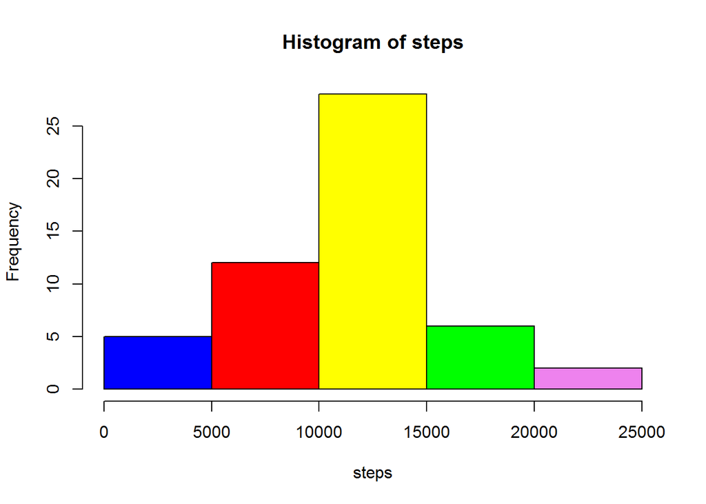

```r
hist(steps, col = c("blue", "red", "yellow", "green", "violet", "orange"))
```

3. Calculate and report the mean and median of the total number of steps taken per day

The mean number of steps taken per day is:

```r
mean(stepsperday$steps)
```

```
## [1] 10766.19
```

The median is:

```r
#mean steps per day
median(stepsperday$steps)
```

```
## [1] 10765
```

## What is the average daily activity pattern?

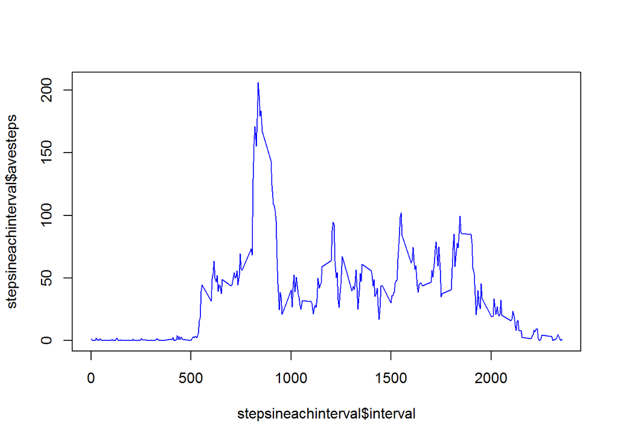

```r
library(plyr)
stepsineachinterval = ddply(cleandata, .(interval), summarize,  avesteps=mean(steps))
plot(stepsineachinterval$interval, stepsineachinterval$avesteps, type = "l", col = "blue")
```

2. Which 5-minute interval, on average across all the days in the dataset, contains the maximum number of steps? Finding the 5 minute interval in which, at an averge, the maximum number of steps were taken.

```r
stepsineachinterval[which.max(stepsineachinterval$avesteps),]
```

```
##     interval avesteps
## 104      835 206.1698
```

## Imputing missing values

```r
# Updating the NA values with average steps in that interval.
# For example, if the observation at 810 is missing, it will be set to the avarage number of steps take in that interval.

# Copy the data to the new dataframe - dataupdated
dataupdated = data
totalrows = nrow(dataupdated)

count = 0
for (i in 1:nrow(dataupdated)) {
  if (is.na(dataupdated[i, 1])) {
    count = count + 1
    matchinginterval = dataupdated[i,3]
    newval = subset(stepsineachinterval, interval == matchinginterval)[1,2]
    dataupdated[i,1] = newval
  }
}
```

Total number of missing values is:

```
## [1] 2304
```

## Histogram with the dataset where NA value is replaced with the average value

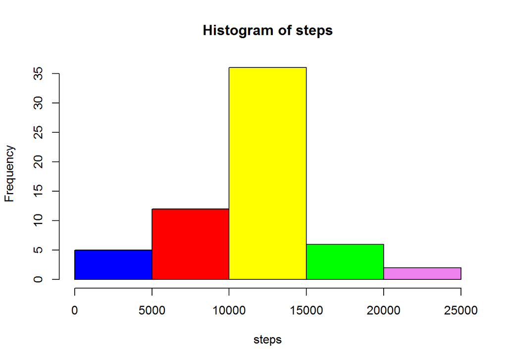

```r
stepsperday = aggregate(steps ~ date, dataupdated, sum)
steps = stepsperday$steps
hist(steps, col = c("blue", "red", "yellow", "green", "violet", "orange"))
```

The mean number of steps taken per day after replacing the missing values is:

```r
mean(stepsperday$steps)
```

```
## [1] 10766.19
```

The median os the steps taken per date after replacing the missing values is:

```r
#mean steps per day
median(stepsperday$steps)
```

```
## [1] 10766.19
```

After replacing the missing values, the mean remains the same as the one before replacing the missing values. However, the median was slightly different before replacing the missing values and now it is same as the mean.

## Are there differences in activity patterns between weekdays and weekends?

1. Creating a new factor variable in the dataset with two levels - “weekday” and “weekend” indicating whether a given date is a weekday or weekend day.

```r
for (i in 1:nrow(dataupdated)) {
  if (isWeekday(as.POSIXlt(dataupdated[i,2], format = "%Y-%m-%d"))) {
    dataupdated[i,4] = "weekday"
  } else {
    dataupdated[i,4] = "weekend"
  }
}
```

Creating an additional column to indicate whether the date is a weekday or a weekend.

```r
databyworkday = aggregate(dataupdated[, 1], list(dataupdated$interval,dataupdated$V4), mean)
# Renaming the column names
colnames(databyworkday) = c("interval", "dayofweek", "numberofsteps")
```

[figure not shown]

```r
qplot(x=databyworkday$interval, y=databyworkday$dayofweek,
       data=databyworkday,
       colour=databyworkday$dayofweek, xlab=c("interval"), ylab=c("Mean number of steps taken"),
       main="Average number of steps in weekdays and weekends") +
     geom_line()
```